# Risk Factor Analysis

## Outcome Variable

**Outcome Variable:** stunted

## Predictor Variables

**Intervention Variable:** exclfeed3

**Adjustment Set:**

unadjusted

## Stratifying Variables

The analysis was stratified on these variable(s):

- agecat
- studyid
- country

## Data Summary

| agecat | studyid | country | exclfeed3 | stunted | n_cell | n | outcome_variable |
| --- | --- | --- | --- | --- | --- | --- | --- |
| Birth | ki0047075b-MAL-ED | BANGLADESH | 1 | 0 | 112 | 215 | stunted |
| Birth | ki0047075b-MAL-ED | BANGLADESH | 1 | 1 | 26 | 215 | stunted |
| Birth | ki0047075b-MAL-ED | BANGLADESH | 0 | 0 | 63 | 215 | stunted |
| Birth | ki0047075b-MAL-ED | BANGLADESH | 0 | 1 | 14 | 215 | stunted |
| Birth | ki0047075b-MAL-ED | BRAZIL | 1 | 0 | 10 | 57 | stunted |
| Birth | ki0047075b-MAL-ED | BRAZIL | 1 | 1 | 2 | 57 | stunted |
| Birth | ki0047075b-MAL-ED | BRAZIL | 0 | 0 | 39 | 57 | stunted |
| Birth | ki0047075b-MAL-ED | BRAZIL | 0 | 1 | 6 | 57 | stunted |
| Birth | ki0047075b-MAL-ED | INDIA | 1 | 0 | 16 | 41 | stunted |
| Birth | ki0047075b-MAL-ED | INDIA | 1 | 1 | 8 | 41 | stunted |
| Birth | ki0047075b-MAL-ED | INDIA | 0 | 0 | 17 | 41 | stunted |
| Birth | ki0047075b-MAL-ED | INDIA | 0 | 1 | 0 | 41 | stunted |
| Birth | ki0047075b-MAL-ED | NEPAL | 1 | 0 | 8 | 26 | stunted |
| Birth | ki0047075b-MAL-ED | NEPAL | 1 | 1 | 0 | 26 | stunted |
| Birth | ki0047075b-MAL-ED | NEPAL | 0 | 0 | 16 | 26 | stunted |
| Birth | ki0047075b-MAL-ED | NEPAL | 0 | 1 | 2 | 26 | stunted |
| Birth | ki0047075b-MAL-ED | PERU | 1 | 0 | 41 | 223 | stunted |
| Birth | ki0047075b-MAL-ED | PERU | 1 | 1 | 8 | 223 | stunted |
| Birth | ki0047075b-MAL-ED | PERU | 0 | 0 | 158 | 223 | stunted |
| Birth | ki0047075b-MAL-ED | PERU | 0 | 1 | 16 | 223 | stunted |
| Birth | ki0047075b-MAL-ED | SOUTH AFRICA | 1 | 0 | 12 | 100 | stunted |
| Birth | ki0047075b-MAL-ED | SOUTH AFRICA | 1 | 1 | 0 | 100 | stunted |
| Birth | ki0047075b-MAL-ED | SOUTH AFRICA | 0 | 0 | 79 | 100 | stunted |
| Birth | ki0047075b-MAL-ED | SOUTH AFRICA | 0 | 1 | 9 | 100 | stunted |
| Birth | ki0047075b-MAL-ED | TANZANIA, UNITED REPUBLIC OF | 1 | 0 | 14 | 102 | stunted |
| Birth | ki0047075b-MAL-ED | TANZANIA, UNITED REPUBLIC OF | 1 | 1 | 3 | 102 | stunted |
| Birth | ki0047075b-MAL-ED | TANZANIA, UNITED REPUBLIC OF | 0 | 0 | 69 | 102 | stunted |
| Birth | ki0047075b-MAL-ED | TANZANIA, UNITED REPUBLIC OF | 0 | 1 | 16 | 102 | stunted |
| Birth | ki1000108-CMC-V-BCS-2002 | INDIA | 1 | 0 | 4 | 4 | stunted |
| Birth | ki1000108-CMC-V-BCS-2002 | INDIA | 1 | 1 | 0 | 4 | stunted |

[output cut: 158 more lines]

The following strata were considered:

- agecat: 24 months, studyid: ki0047075b-MAL-ED, country: BANGLADESH
- agecat: 24 months, studyid: ki0047075b-MAL-ED, country: BRAZIL
- agecat: 24 months, studyid: ki0047075b-MAL-ED, country: INDIA
- agecat: 24 months, studyid: ki0047075b-MAL-ED, country: NEPAL
- agecat: 24 months, studyid: ki0047075b-MAL-ED, country: PERU
- agecat: 24 months, studyid: ki0047075b-MAL-ED, country: SOUTH AFRICA
- agecat: 24 months, studyid: ki0047075b-MAL-ED, country: TANZANIA, UNITED REPUBLIC OF
- agecat: 24 months, studyid: ki1000108-CMC-V-BCS-2002, country: INDIA
- agecat: 24 months, studyid: ki1000108-IRC, country: INDIA
- agecat: 24 months, studyid: ki1000109-EE, country: PAKISTAN
- agecat: 24 months, studyid: ki1017093b-PROVIDE, country: BANGLADESH
- agecat: 24 months, studyid: ki1101329-Keneba, country: GAMBIA
- agecat: 24 months, studyid: ki1113344-GMS-Nepal, country: NEPAL
- agecat: 24 months, studyid: kiGH5241-JiVitA-3, country: BANGLADESH
- agecat: 24 months, studyid: kiGH5241-JiVitA-4, country: BANGLADESH
- agecat: 6 months, studyid: ki0047075b-MAL-ED, country: BANGLADESH
- agecat: 6 months, studyid: ki0047075b-MAL-ED, country: BRAZIL
- agecat: 6 months, studyid: ki0047075b-MAL-ED, country: INDIA
- agecat: 6 months, studyid: ki0047075b-MAL-ED, country: NEPAL
- agecat: 6 months, studyid: ki0047075b-MAL-ED, country: PERU
- agecat: 6 months, studyid: ki0047075b-MAL-ED, country: SOUTH AFRICA
- agecat: 6 months, studyid: ki0047075b-MAL-ED, country: TANZANIA, UNITED REPUBLIC OF
- agecat: 6 months, studyid: ki1000108-CMC-V-BCS-2002, country: INDIA
- agecat: 6 months, studyid: ki1000108-IRC, country: INDIA
- agecat: 6 months, studyid: ki1000109-EE, country: PAKISTAN
- agecat: 6 months, studyid: ki1000304b-SAS-CompFeed, country: INDIA
- agecat: 6 months, studyid: ki1017093b-PROVIDE, country: BANGLADESH
- agecat: 6 months, studyid: ki1101329-Keneba, country: GAMBIA
- agecat: 6 months, studyid: ki1113344-GMS-Nepal, country: NEPAL
- agecat: 6 months, studyid: kiGH5241-JiVitA-3, country: BANGLADESH
- agecat: 6 months, studyid: kiGH5241-JiVitA-4, country: BANGLADESH
- agecat: Birth, studyid: ki0047075b-MAL-ED, country: BANGLADESH
- agecat: Birth, studyid: ki0047075b-MAL-ED, country: BRAZIL
- agecat: Birth, studyid: ki0047075b-MAL-ED, country: INDIA
- agecat: Birth, studyid: ki0047075b-MAL-ED, country: NEPAL
- agecat: Birth, studyid: ki0047075b-MAL-ED, country: PERU
- agecat: Birth, studyid: ki0047075b-MAL-ED, country: SOUTH AFRICA
- agecat: Birth, studyid: ki0047075b-MAL-ED, country: TANZANIA, UNITED REPUBLIC OF
- agecat: Birth, studyid: ki1000108-CMC-V-BCS-2002, country: INDIA
- agecat: Birth, studyid: ki1000108-IRC, country: INDIA
- agecat: Birth, studyid: ki1000109-EE, country: PAKISTAN
- agecat: Birth, studyid: ki1000304b-SAS-CompFeed, country: INDIA
- agecat: Birth, studyid: ki1017093b-PROVIDE, country: BANGLADESH
- agecat: Birth, studyid: ki1101329-Keneba, country: GAMBIA
- agecat: Birth, studyid: ki1113344-GMS-Nepal, country: NEPAL
- agecat: Birth, studyid: kiGH5241-JiVitA-3, country: BANGLADESH
- agecat: Birth, studyid: kiGH5241-JiVitA-4, country: BANGLADESH

### Dropped Strata

Some strata were dropped due to rare outcomes:

- agecat: Birth, studyid: ki0047075b-MAL-ED, country: BRAZIL
- agecat: Birth, studyid: ki0047075b-MAL-ED, country: INDIA
- agecat: Birth, studyid: ki0047075b-MAL-ED, country: NEPAL
- agecat: Birth, studyid: ki0047075b-MAL-ED, country: SOUTH AFRICA
- agecat: Birth, studyid: ki0047075b-MAL-ED, country: TANZANIA, UNITED REPUBLIC OF
- agecat: Birth, studyid: ki1000108-CMC-V-BCS-2002, country: INDIA
- agecat: Birth, studyid: ki1000108-IRC, country: INDIA
- agecat: Birth, studyid: ki1000109-EE, country: PAKISTAN
- agecat: Birth, studyid: kiGH5241-JiVitA-4, country: BANGLADESH
- agecat: 6 months, studyid: ki0047075b-MAL-ED, country: BRAZIL
- agecat: 6 months, studyid: ki0047075b-MAL-ED, country: NEPAL
- agecat: 6 months, studyid: ki0047075b-MAL-ED, country: SOUTH AFRICA
- agecat: 6 months, studyid: ki1000108-CMC-V-BCS-2002, country: INDIA
- agecat: 6 months, studyid: ki1000108-IRC, country: INDIA
- agecat: 6 months, studyid: ki1000109-EE, country: PAKISTAN
- agecat: 6 months, studyid: kiGH5241-JiVitA-4, country: BANGLADESH
- agecat: 24 months, studyid: ki0047075b-MAL-ED, country: BRAZIL
- agecat: 24 months, studyid: ki1000108-CMC-V-BCS-2002, country: INDIA
- agecat: 24 months, studyid: ki1000108-IRC, country: INDIA
- agecat: 24 months, studyid: ki1000109-EE, country: PAKISTAN

## Methods Detail

We’re interested in the causal parameters $E[Y_a]$ for all values of $a \in \mathcal{A}$. These parameters represent the mean outcome if, possibly contrary to fact, we intervened to set all units to have $A=a$. Under the randomization and positivity assumptions, these are identified by the statistical parameters $\psi_a=E_W[E_{Y|A,W}(Y|A=a,W)]$. In addition, we’re interested in the mean of $Y$, $E[Y]$ under no intervention (the observed mean). We will estimate these parameters by using SuperLearner to fit the relevant likelihood factors – $E_{Y|A,W}(Y|A=a,W)$ and $p(A=a|W)$, and then updating our likelihood fit using a joint TMLE.

For unadjusted analyses ($W=\{\}$), initial likelihoods were estimated using Lrnr_glm to estimate the simple $E(Y|A)$ and Lrnr_mean to estimate $p(A)$. For adjusted analyses, a small library containing Lrnr_glmnet, Lrnr_xgboost, and Lrnr_mean was used.

Having estimated these parameters, we will then use the delta method to estimate relative risks and attributable risks relative to a prespecified baseline level of $A$.

# Results Detail

## Results Plots

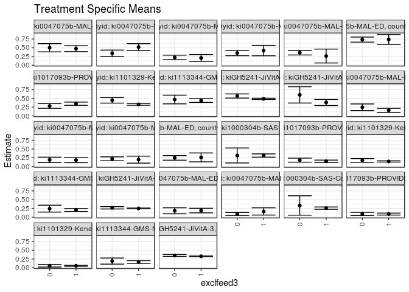

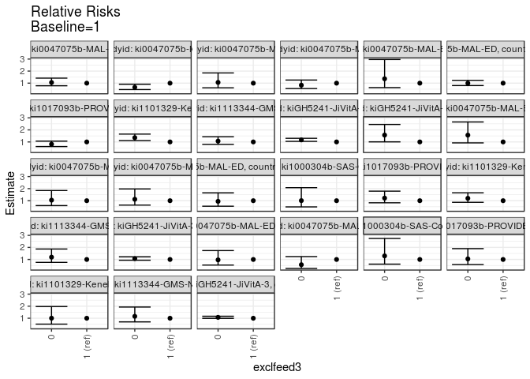

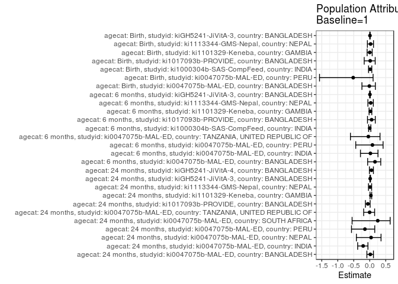

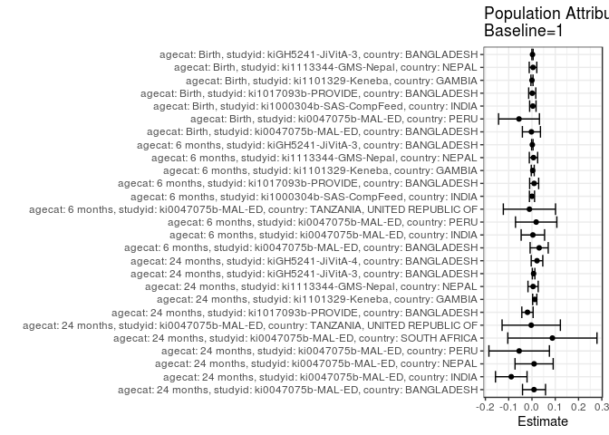

## Results Table

### Parameter: TSM

| agecat | studyid | country | intervention_level | baseline_level | estimate | ci_lower | ci_upper |
| --- | --- | --- | --- | --- | --- | --- | --- |
| Birth | ki0047075b-MAL-ED | BANGLADESH | 1 | NA | 0.1884058 | 0.1230119 | 0.2537997 |
| Birth | ki0047075b-MAL-ED | BANGLADESH | 0 | NA | 0.1818182 | 0.0954689 | 0.2681674 |
| Birth | ki0047075b-MAL-ED | PERU | 1 | NA | 0.1632653 | 0.0595443 | 0.2669863 |
| Birth | ki0047075b-MAL-ED | PERU | 0 | NA | 0.0919540 | 0.0489223 | 0.1349857 |
| Birth | ki1000304b-SAS-CompFeed | INDIA | 1 | NA | 0.2572254 | 0.2236819 | 0.2907690 |
| Birth | ki1000304b-SAS-CompFeed | INDIA | 0 | NA | 0.3333333 | 0.0564891 | 0.6101775 |
| Birth | ki1017093b-PROVIDE | BANGLADESH | 1 | NA | 0.0878553 | 0.0596252 | 0.1160854 |
| Birth | ki1017093b-PROVIDE | BANGLADESH | 0 | NA | 0.0921053 | 0.0460913 | 0.1381192 |
| Birth | ki1101329-Keneba | GAMBIA | 1 | NA | 0.0567613 | 0.0436539 | 0.0698687 |
| Birth | ki1101329-Keneba | GAMBIA | 0 | NA | 0.0569620 | 0.0208096 | 0.0931144 |
| Birth | ki1113344-GMS-Nepal | NEPAL | 1 | NA | 0.1657895 | 0.1283571 | 0.2032218 |
| Birth | ki1113344-GMS-Nepal | NEPAL | 0 | NA | 0.1923077 | 0.1047495 | 0.2798659 |
| Birth | kiGH5241-JiVitA-3 | BANGLADESH | 1 | NA | 0.3277843 | 0.3183050 | 0.3372635 |
| Birth | kiGH5241-JiVitA-3 | BANGLADESH | 0 | NA | 0.3518225 | 0.3245233 | 0.3791217 |
| 6 months | ki0047075b-MAL-ED | BANGLADESH | 1 | NA | 0.1578947 | 0.0998013 | 0.2159882 |
| 6 months | ki0047075b-MAL-ED | BANGLADESH | 0 | NA | 0.2469136 | 0.1528039 | 0.3410233 |
| 6 months | ki0047075b-MAL-ED | INDIA | 1 | NA | 0.1818182 | 0.1095692 | 0.2540672 |
| 6 months | ki0047075b-MAL-ED | INDIA | 0 | NA | 0.1900000 | 0.1129267 | 0.2670733 |
| 6 months | ki0047075b-MAL-ED | PERU | 1 | NA | 0.1967213 | 0.0967794 | 0.2966632 |
| 6 months | ki0047075b-MAL-ED | PERU | 0 | NA | 0.2200957 | 0.1638218 | 0.2763696 |
| 6 months | ki0047075b-MAL-ED | TANZANIA, UNITED REPUBLIC OF | 1 | NA | 0.2608696 | 0.1336751 | 0.3880640 |
| 6 months | ki0047075b-MAL-ED | TANZANIA, UNITED REPUBLIC OF | 0 | NA | 0.2469880 | 0.1812283 | 0.3127476 |
| 6 months | ki1000304b-SAS-CompFeed | INDIA | 1 | NA | 0.3139842 | 0.2679102 | 0.3600581 |
| 6 months | ki1000304b-SAS-CompFeed | INDIA | 0 | NA | 0.3157895 | 0.1014523 | 0.5301266 |
| 6 months | ki1017093b-PROVIDE | BANGLADESH | 1 | NA | 0.1495327 | 0.1157198 | 0.1833456 |
| 6 months | ki1017093b-PROVIDE | BANGLADESH | 0 | NA | 0.1818182 | 0.1247893 | 0.2388471 |
| 6 months | ki1101329-Keneba | GAMBIA | 1 | NA | 0.1453602 | 0.1277572 | 0.1629631 |
| 6 months | ki1101329-Keneba | GAMBIA | 0 | NA | 0.1741294 | 0.1216889 | 0.2265698 |
| 6 months | ki1113344-GMS-Nepal | NEPAL | 1 | NA | 0.2043597 | 0.1630583 | 0.2456610 |
| 6 months | ki1113344-GMS-Nepal | NEPAL | 0 | NA | 0.2432432 | 0.1453791 | 0.3411074 |
| 6 months | kiGH5241-JiVitA-3 | BANGLADESH | 1 | NA | 0.2493540 | 0.2384552 | 0.2602529 |
| 6 months | kiGH5241-JiVitA-3 | BANGLADESH | 0 | NA | 0.2665848 | 0.2332624 | 0.2999071 |
| 24 months | ki0047075b-MAL-ED | BANGLADESH | 1 | NA | 0.4740741 | 0.3896379 | 0.5585102 |
| 24 months | ki0047075b-MAL-ED | BANGLADESH | 0 | NA | 0.5000000 | 0.3825830 | 0.6174170 |
| 24 months | ki0047075b-MAL-ED | INDIA | 1 | NA | 0.5196078 | 0.4224089 | 0.6168068 |
| 24 months | ki0047075b-MAL-ED | INDIA | 0 | NA | 0.3400000 | 0.2469241 | 0.4330759 |
| 24 months | ki0047075b-MAL-ED | NEPAL | 1 | NA | 0.2089552 | 0.1113828 | 0.3065277 |
| 24 months | ki0047075b-MAL-ED | NEPAL | 0 | NA | 0.2222222 | 0.1561965 | 0.2882479 |
| 24 months | ki0047075b-MAL-ED | PERU | 1 | NA | 0.4186047 | 0.2707785 | 0.5664308 |
| 24 months | ki0047075b-MAL-ED | PERU | 0 | NA | 0.3483871 | 0.2731889 | 0.4235853 |
| 24 months | ki0047075b-MAL-ED | SOUTH AFRICA | 1 | NA | 0.2631579 | 0.0647216 | 0.4615942 |
| 24 months | ki0047075b-MAL-ED | SOUTH AFRICA | 0 | NA | 0.3588517 | 0.2936789 | 0.4240244 |
| 24 months | ki0047075b-MAL-ED | TANZANIA, UNITED REPUBLIC OF | 1 | NA | 0.7368421 | 0.5964525 | 0.8772318 |
| 24 months | ki0047075b-MAL-ED | TANZANIA, UNITED REPUBLIC OF | 0 | NA | 0.7328767 | 0.6609109 | 0.8048425 |
| 24 months | ki1017093b-PROVIDE | BANGLADESH | 1 | NA | 0.3480392 | 0.3017778 | 0.3943006 |
| 24 months | ki1017093b-PROVIDE | BANGLADESH | 0 | NA | 0.2823529 | 0.2146276 | 0.3500783 |
| 24 months | ki1101329-Keneba | GAMBIA | 1 | NA | 0.3288854 | 0.3030784 | 0.3546924 |
| 24 months | ki1101329-Keneba | GAMBIA | 0 | NA | 0.4452055 | 0.3645617 | 0.5258493 |
| 24 months | ki1113344-GMS-Nepal | NEPAL | 1 | NA | 0.4378882 | 0.3836283 | 0.4921481 |
| 24 months | ki1113344-GMS-Nepal | NEPAL | 0 | NA | 0.4677419 | 0.3433814 | 0.5921025 |
| 24 months | kiGH5241-JiVitA-3 | BANGLADESH | 1 | NA | 0.4868035 | 0.4691434 | 0.5044637 |
| 24 months | kiGH5241-JiVitA-3 | BANGLADESH | 0 | NA | 0.5680191 | 0.5091045 | 0.6269337 |
| 24 months | kiGH5241-JiVitA-4 | BANGLADESH | 1 | NA | 0.3823529 | 0.2957347 | 0.4689712 |
| 24 months | kiGH5241-JiVitA-4 | BANGLADESH | 0 | NA | 0.6000000 | 0.3670443 | 0.8329557 |

### Parameter: E(Y)

| agecat | studyid | country | intervention_level | baseline_level | estimate | ci_lower | ci_upper |
| --- | --- | --- | --- | --- | --- | --- | --- |
| Birth | ki0047075b-MAL-ED | BANGLADESH | NA | NA | 0.1860465 | 0.1339088 | 0.2381842 |
| Birth | ki0047075b-MAL-ED | PERU | NA | NA | 0.1076233 | 0.0668572 | 0.1483894 |
| Birth | ki1000304b-SAS-CompFeed | INDIA | NA | NA | 0.2609890 | 0.2179233 | 0.3040547 |
| Birth | ki1017093b-PROVIDE | BANGLADESH | NA | NA | 0.0890538 | 0.0649864 | 0.1131212 |
| Birth | ki1101329-Keneba | GAMBIA | NA | NA | 0.0567847 | 0.0444621 | 0.0691072 |
| Birth | ki1113344-GMS-Nepal | NEPAL | NA | NA | 0.1703057 | 0.1358418 | 0.2047695 |
| Birth | kiGH5241-JiVitA-3 | BANGLADESH | NA | NA | 0.3300693 | 0.3209240 | 0.3392146 |
| 6 months | ki0047075b-MAL-ED | BANGLADESH | NA | NA | 0.1888412 | 0.1384789 | 0.2392035 |
| 6 months | ki0047075b-MAL-ED | INDIA | NA | NA | 0.1857143 | 0.1329930 | 0.2384356 |
| 6 months | ki0047075b-MAL-ED | PERU | NA | NA | 0.2148148 | 0.1657364 | 0.2638932 |
| 6 months | ki0047075b-MAL-ED | TANZANIA, UNITED REPUBLIC OF | NA | NA | 0.2500000 | 0.1915738 | 0.3084262 |
| 6 months | ki1000304b-SAS-CompFeed | INDIA | NA | NA | 0.3140704 | 0.2712850 | 0.3568557 |
| 6 months | ki1017093b-PROVIDE | BANGLADESH | NA | NA | 0.1589404 | 0.1297581 | 0.1881227 |
| 6 months | ki1101329-Keneba | GAMBIA | NA | NA | 0.1486797 | 0.1319680 | 0.1653914 |
| 6 months | ki1113344-GMS-Nepal | NEPAL | NA | NA | 0.2108844 | 0.1727677 | 0.2490010 |
| 6 months | kiGH5241-JiVitA-3 | BANGLADESH | NA | NA | 0.2508576 | 0.2404565 | 0.2612588 |
| 24 months | ki0047075b-MAL-ED | BANGLADESH | NA | NA | 0.4829268 | 0.4143544 | 0.5514993 |
| 24 months | ki0047075b-MAL-ED | INDIA | NA | NA | 0.4306931 | 0.3622377 | 0.4991484 |
| 24 months | ki0047075b-MAL-ED | NEPAL | NA | NA | 0.2181818 | 0.1634817 | 0.2728819 |
| 24 months | ki0047075b-MAL-ED | PERU | NA | NA | 0.3636364 | 0.2964623 | 0.4308104 |
| 24 months | ki0047075b-MAL-ED | SOUTH AFRICA | NA | NA | 0.3508772 | 0.2887937 | 0.4129607 |
| 24 months | ki0047075b-MAL-ED | TANZANIA, UNITED REPUBLIC OF | NA | NA | 0.7336957 | 0.6696530 | 0.7977384 |
| 24 months | ki1017093b-PROVIDE | BANGLADESH | NA | NA | 0.3287197 | 0.2903909 | 0.3670485 |
| 24 months | ki1101329-Keneba | GAMBIA | NA | NA | 0.3408451 | 0.3161830 | 0.3655071 |
| 24 months | ki1113344-GMS-Nepal | NEPAL | NA | NA | 0.4427083 | 0.3929634 | 0.4924533 |
| 24 months | kiGH5241-JiVitA-3 | BANGLADESH | NA | NA | 0.4938170 | 0.4765272 | 0.5111067 |
| 24 months | kiGH5241-JiVitA-4 | BANGLADESH | NA | NA | 0.4039735 | 0.3218653 | 0.4860818 |

### Parameter: RR

| agecat | studyid | country | intervention_level | baseline_level | estimate | ci_lower | ci_upper |
| --- | --- | --- | --- | --- | --- | --- | --- |
| Birth | ki0047075b-MAL-ED | BANGLADESH | 1 | 1 | 1.0000000 | 1.0000000 | 1.0000000 |
| Birth | ki0047075b-MAL-ED | BANGLADESH | 0 | 1 | 0.9650350 | 0.5358895 | 1.7378442 |
| Birth | ki0047075b-MAL-ED | PERU | 1 | 1 | 1.0000000 | 1.0000000 | 1.0000000 |
| Birth | ki0047075b-MAL-ED | PERU | 0 | 1 | 0.5632184 | 0.2558581 | 1.2398080 |
| Birth | ki1000304b-SAS-CompFeed | INDIA | 1 | 1 | 1.0000000 | 1.0000000 | 1.0000000 |
| Birth | ki1000304b-SAS-CompFeed | INDIA | 0 | 1 | 1.2958801 | 0.6113712 | 2.7467853 |
| Birth | ki1017093b-PROVIDE | BANGLADESH | 1 | 1 | 1.0000000 | 1.0000000 | 1.0000000 |
| Birth | ki1017093b-PROVIDE | BANGLADESH | 0 | 1 | 1.0483746 | 0.5788258 | 1.8988256 |
| Birth | ki1101329-Keneba | GAMBIA | 1 | 1 | 1.0000000 | 1.0000000 | 1.0000000 |
| Birth | ki1101329-Keneba | GAMBIA | 0 | 1 | 1.0035369 | 0.5107633 | 1.9717278 |
| Birth | ki1113344-GMS-Nepal | NEPAL | 1 | 1 | 1.0000000 | 1.0000000 | 1.0000000 |
| Birth | ki1113344-GMS-Nepal | NEPAL | 0 | 1 | 1.1599512 | 0.6977930 | 1.9282033 |
| Birth | kiGH5241-JiVitA-3 | BANGLADESH | 1 | 1 | 1.0000000 | 1.0000000 | 1.0000000 |
| Birth | kiGH5241-JiVitA-3 | BANGLADESH | 0 | 1 | 1.0733356 | 0.9900302 | 1.1636507 |
| 6 months | ki0047075b-MAL-ED | BANGLADESH | 1 | 1 | 1.0000000 | 1.0000000 | 1.0000000 |
| 6 months | ki0047075b-MAL-ED | BANGLADESH | 0 | 1 | 1.5637860 | 0.9206781 | 2.6561149 |
| 6 months | ki0047075b-MAL-ED | INDIA | 1 | 1 | 1.0000000 | 1.0000000 | 1.0000000 |
| 6 months | ki0047075b-MAL-ED | INDIA | 0 | 1 | 1.0450000 | 0.5922461 | 1.8438703 |
| 6 months | ki0047075b-MAL-ED | PERU | 1 | 1 | 1.0000000 | 1.0000000 | 1.0000000 |
| 6 months | ki0047075b-MAL-ED | PERU | 0 | 1 | 1.1188198 | 0.6335135 | 1.9758975 |
| 6 months | ki0047075b-MAL-ED | TANZANIA, UNITED REPUBLIC OF | 1 | 1 | 1.0000000 | 1.0000000 | 1.0000000 |
| 6 months | ki0047075b-MAL-ED | TANZANIA, UNITED REPUBLIC OF | 0 | 1 | 0.9467871 | 0.5432330 | 1.6501314 |
| 6 months | ki1000304b-SAS-CompFeed | INDIA | 1 | 1 | 1.0000000 | 1.0000000 | 1.0000000 |
| 6 months | ki1000304b-SAS-CompFeed | INDIA | 0 | 1 | 1.0057497 | 0.4866253 | 2.0786680 |
| 6 months | ki1017093b-PROVIDE | BANGLADESH | 1 | 1 | 1.0000000 | 1.0000000 | 1.0000000 |
| 6 months | ki1017093b-PROVIDE | BANGLADESH | 0 | 1 | 1.2159091 | 0.8259851 | 1.7899050 |
| 6 months | ki1101329-Keneba | GAMBIA | 1 | 1 | 1.0000000 | 1.0000000 | 1.0000000 |
| 6 months | ki1101329-Keneba | GAMBIA | 0 | 1 | 1.1979167 | 0.8658791 | 1.6572803 |
| 6 months | ki1113344-GMS-Nepal | NEPAL | 1 | 1 | 1.0000000 | 1.0000000 | 1.0000000 |
| 6 months | ki1113344-GMS-Nepal | NEPAL | 0 | 1 | 1.1902703 | 0.7587688 | 1.8671606 |
| 6 months | kiGH5241-JiVitA-3 | BANGLADESH | 1 | 1 | 1.0000000 | 1.0000000 | 1.0000000 |
| 6 months | kiGH5241-JiVitA-3 | BANGLADESH | 0 | 1 | 1.0691016 | 0.9370218 | 1.2197989 |
| 24 months | ki0047075b-MAL-ED | BANGLADESH | 1 | 1 | 1.0000000 | 1.0000000 | 1.0000000 |
| 24 months | ki0047075b-MAL-ED | BANGLADESH | 0 | 1 | 1.0546875 | 0.7854555 | 1.4162046 |
| 24 months | ki0047075b-MAL-ED | INDIA | 1 | 1 | 1.0000000 | 1.0000000 | 1.0000000 |
| 24 months | ki0047075b-MAL-ED | INDIA | 0 | 1 | 0.6543396 | 0.4696865 | 0.9115875 |
| 24 months | ki0047075b-MAL-ED | NEPAL | 1 | 1 | 1.0000000 | 1.0000000 | 1.0000000 |
| 24 months | ki0047075b-MAL-ED | NEPAL | 0 | 1 | 1.0634921 | 0.6114591 | 1.8496991 |
| 24 months | ki0047075b-MAL-ED | PERU | 1 | 1 | 1.0000000 | 1.0000000 | 1.0000000 |
| 24 months | ki0047075b-MAL-ED | PERU | 0 | 1 | 0.8322581 | 0.5501886 | 1.2589382 |
| 24 months | ki0047075b-MAL-ED | SOUTH AFRICA | 1 | 1 | 1.0000000 | 1.0000000 | 1.0000000 |
| 24 months | ki0047075b-MAL-ED | SOUTH AFRICA | 0 | 1 | 1.3636364 | 0.6278426 | 2.9617362 |
| 24 months | ki0047075b-MAL-ED | TANZANIA, UNITED REPUBLIC OF | 1 | 1 | 1.0000000 | 1.0000000 | 1.0000000 |
| 24 months | ki0047075b-MAL-ED | TANZANIA, UNITED REPUBLIC OF | 0 | 1 | 0.9946184 | 0.8027266 | 1.2323819 |
| 24 months | ki1017093b-PROVIDE | BANGLADESH | 1 | 1 | 1.0000000 | 1.0000000 | 1.0000000 |
| 24 months | ki1017093b-PROVIDE | BANGLADESH | 0 | 1 | 0.8112676 | 0.6166923 | 1.0672342 |
| 24 months | ki1101329-Keneba | GAMBIA | 1 | 1 | 1.0000000 | 1.0000000 | 1.0000000 |
| 24 months | ki1101329-Keneba | GAMBIA | 0 | 1 | 1.3536797 | 1.1111801 | 1.6491014 |
| 24 months | ki1113344-GMS-Nepal | NEPAL | 1 | 1 | 1.0000000 | 1.0000000 | 1.0000000 |
| 24 months | ki1113344-GMS-Nepal | NEPAL | 0 | 1 | 1.0681766 | 0.7966190 | 1.4323048 |
| 24 months | kiGH5241-JiVitA-3 | BANGLADESH | 1 | 1 | 1.0000000 | 1.0000000 | 1.0000000 |
| 24 months | kiGH5241-JiVitA-3 | BANGLADESH | 0 | 1 | 1.1668344 | 1.0473344 | 1.2999693 |
| 24 months | kiGH5241-JiVitA-4 | BANGLADESH | 1 | 1 | 1.0000000 | 1.0000000 | 1.0000000 |
| 24 months | kiGH5241-JiVitA-4 | BANGLADESH | 0 | 1 | 1.5692308 | 1.0057767 | 2.4483420 |

### Parameter: PAR

| agecat | studyid | country | intervention_level | baseline_level | estimate | ci_lower | ci_upper |
| --- | --- | --- | --- | --- | --- | --- | --- |
| Birth | ki0047075b-MAL-ED | BANGLADESH | 1 | NA | -0.0023593 | -0.0411542 | 0.0364356 |
| Birth | ki0047075b-MAL-ED | PERU | 1 | NA | -0.0556420 | -0.1433470 | 0.0320630 |
| Birth | ki1000304b-SAS-CompFeed | INDIA | 1 | NA | 0.0037636 | -0.0100156 | 0.0175428 |
| Birth | ki1017093b-PROVIDE | BANGLADESH | 1 | NA | 0.0011985 | -0.0140259 | 0.0164229 |
| Birth | ki1101329-Keneba | GAMBIA | 1 | NA | 0.0000234 | -0.0044574 | 0.0045042 |
| Birth | ki1113344-GMS-Nepal | NEPAL | 1 | NA | 0.0045162 | -0.0117267 | 0.0207591 |
| Birth | kiGH5241-JiVitA-3 | BANGLADESH | 1 | NA | 0.0022850 | -0.0004001 | 0.0049702 |
| 6 months | ki0047075b-MAL-ED | BANGLADESH | 1 | NA | 0.0309465 | -0.0078861 | 0.0697791 |
| 6 months | ki0047075b-MAL-ED | INDIA | 1 | NA | 0.0038961 | -0.0464126 | 0.0542048 |
| 6 months | ki0047075b-MAL-ED | PERU | 1 | NA | 0.0180935 | -0.0706973 | 0.1068843 |
| 6 months | ki0047075b-MAL-ED | TANZANIA, UNITED REPUBLIC OF | 1 | NA | -0.0108696 | -0.1229910 | 0.1012519 |
| 6 months | ki1000304b-SAS-CompFeed | INDIA | 1 | NA | 0.0000862 | -0.0108674 | 0.0110398 |
| 6 months | ki1017093b-PROVIDE | BANGLADESH | 1 | NA | 0.0094077 | -0.0099468 | 0.0287622 |
| 6 months | ki1101329-Keneba | GAMBIA | 1 | NA | 0.0033195 | -0.0030777 | 0.0097167 |
| 6 months | ki1113344-GMS-Nepal | NEPAL | 1 | NA | 0.0065247 | -0.0113511 | 0.0244005 |
| 6 months | kiGH5241-JiVitA-3 | BANGLADESH | 1 | NA | 0.0015036 | -0.0015538 | 0.0045610 |
| 24 months | ki0047075b-MAL-ED | BANGLADESH | 1 | NA | 0.0088528 | -0.0405600 | 0.0582655 |
| 24 months | ki0047075b-MAL-ED | INDIA | 1 | NA | -0.0889148 | -0.1566834 | -0.0211461 |
| 24 months | ki0047075b-MAL-ED | NEPAL | 1 | NA | 0.0092266 | -0.0727106 | 0.0911638 |
| 24 months | ki0047075b-MAL-ED | PERU | 1 | NA | -0.0549683 | -0.1848659 | 0.0749293 |
| 24 months | ki0047075b-MAL-ED | SOUTH AFRICA | 1 | NA | 0.0877193 | -0.1037709 | 0.2792095 |
| 24 months | ki0047075b-MAL-ED | TANZANIA, UNITED REPUBLIC OF | 1 | NA | -0.0031465 | -0.1283261 | 0.1220332 |
| 24 months | ki1017093b-PROVIDE | BANGLADESH | 1 | NA | -0.0193195 | -0.0435655 | 0.0049265 |
| 24 months | ki1101329-Keneba | GAMBIA | 1 | NA | 0.0119597 | 0.0030620 | 0.0208574 |
| 24 months | ki1113344-GMS-Nepal | NEPAL | 1 | NA | 0.0048201 | -0.0171145 | 0.0267548 |
| 24 months | kiGH5241-JiVitA-3 | BANGLADESH | 1 | NA | 0.0070135 | 0.0015571 | 0.0124698 |
| 24 months | kiGH5241-JiVitA-4 | BANGLADESH | 1 | NA | 0.0216206 | -0.0032699 | 0.0465111 |

### Parameter: PAF

| agecat | studyid | country | intervention_level | baseline_level | estimate | ci_lower | ci_upper |
| --- | --- | --- | --- | --- | --- | --- | --- |
| Birth | ki0047075b-MAL-ED | BANGLADESH | 1 | NA | -0.0126812 | -0.2442049 | 0.1757603 |
| Birth | ki0047075b-MAL-ED | PERU | 1 | NA | -0.5170068 | -1.5702556 | 0.1046378 |
| Birth | ki1000304b-SAS-CompFeed | INDIA | 1 | NA | 0.0144204 | -0.0378960 | 0.0640998 |
| Birth | ki1017093b-PROVIDE | BANGLADESH | 1 | NA | 0.0134582 | -0.1731686 | 0.1703966 |
| Birth | ki1101329-Keneba | GAMBIA | 1 | NA | 0.0004119 | -0.0816941 | 0.0762858 |
| Birth | ki1113344-GMS-Nepal | NEPAL | 1 | NA | 0.0265182 | -0.0735854 | 0.1172879 |
| Birth | kiGH5241-JiVitA-3 | BANGLADESH | 1 | NA | 0.0069229 | -0.0012441 | 0.0150233 |
| 6 months | ki0047075b-MAL-ED | BANGLADESH | 1 | NA | 0.1638756 | -0.0656087 | 0.3439393 |
| 6 months | ki0047075b-MAL-ED | INDIA | 1 | NA | 0.0209790 | -0.2910537 | 0.2575971 |
| 6 months | ki0047075b-MAL-ED | PERU | 1 | NA | 0.0842284 | -0.4378095 | 0.4167255 |
| 6 months | ki0047075b-MAL-ED | TANZANIA, UNITED REPUBLIC OF | 1 | NA | -0.0434783 | -0.6037184 | 0.3210486 |
| 6 months | ki1000304b-SAS-CompFeed | INDIA | 1 | NA | 0.0002744 | -0.0352245 | 0.0345560 |
| 6 months | ki1017093b-PROVIDE | BANGLADESH | 1 | NA | 0.0591900 | -0.0704578 | 0.1731357 |
| 6 months | ki1101329-Keneba | GAMBIA | 1 | NA | 0.0223267 | -0.0216106 | 0.0643743 |
| 6 months | ki1113344-GMS-Nepal | NEPAL | 1 | NA | 0.0309396 | -0.0575470 | 0.1120224 |
| 6 months | kiGH5241-JiVitA-3 | BANGLADESH | 1 | NA | 0.0059939 | -0.0062763 | 0.0181146 |
| 24 months | ki0047075b-MAL-ED | BANGLADESH | 1 | NA | 0.0183315 | -0.0895411 | 0.1155238 |
| 24 months | ki0047075b-MAL-ED | INDIA | 1 | NA | -0.2064458 | -0.3777084 | -0.0564728 |
| 24 months | ki0047075b-MAL-ED | NEPAL | 1 | NA | 0.0422886 | -0.4174316 | 0.3529062 |
| 24 months | ki0047075b-MAL-ED | PERU | 1 | NA | -0.1511628 | -0.5704821 | 0.1561981 |
| 24 months | ki0047075b-MAL-ED | SOUTH AFRICA | 1 | NA | 0.2500000 | -0.5519753 | 0.6375587 |
| 24 months | ki0047075b-MAL-ED | TANZANIA, UNITED REPUBLIC OF | 1 | NA | -0.0042885 | -0.1902553 | 0.1526227 |
| 24 months | ki1017093b-PROVIDE | BANGLADESH | 1 | NA | -0.0587719 | -0.1351735 | 0.0124875 |
| 24 months | ki1101329-Keneba | GAMBIA | 1 | NA | 0.0350883 | 0.0086274 | 0.0608429 |
| 24 months | ki1113344-GMS-Nepal | NEPAL | 1 | NA | 0.0108878 | -0.0399297 | 0.0592221 |
| 24 months | kiGH5241-JiVitA-3 | BANGLADESH | 1 | NA | 0.0142026 | 0.0031247 | 0.0251573 |
| 24 months | kiGH5241-JiVitA-4 | BANGLADESH | 1 | NA | 0.0535198 | -0.0115565 | 0.1144095 |